# fastQC reports

Sébastien Renaut (sebastien.renaut@criucpq.ulaval.ca)

2023-03-31 13:07:52

# 1 Introduction

- This is a fastQC report of raw sequences. I uses functions from `fastqcr`, which is itself a wrapper for [`fastqc`](https://www.bioinformatics.babraham.ac.uk/projects/fastqc/)
- You can knit this directly from `Rstudio` or you can create this document by running `Rscript -e "rmarkdown::render('fastqc_reports.Rmd',params = list())"` on a Linux/Unix machine.

```r
library(fastqcr)
library(DT)
library(readxl)
```

```r
library(dplyr)
library(ggplot2)
library(tidyr)
```

# 2 FastQC parameters

```r
print(params)
```

```
## $fq.dir
## [1] "C:/Users/renseb01/Documents/rnaseq/data/fastq2"
##
## $qc.dir
## [1] "C:/Users/renseb01/Documents/rnaseq/data/fastqc_results"
##
## $threads
## [1] 12
##
## $fastqc.path
## [1] "C:/Program\\ Files/FastQC/fastqc"
##
## $metadata
## [1] "C:/Users/renseb01/Documents/rnaseq/data/librairies_1_a_70_et_RIN.xlsx"
##
## $adapters.dir
## NULL
```

# 3 Running FastQC functions

```r
fastqc_statistics= fastqcr_wrapper(fq.dir = params$fq.dir,
                qc.dir = params$qc.dir,
                threads = params$threads,
                fastqc.path = params$fastqc.path,
                metadata = params$metadata,
                adapters.dir = params$adapters.dir)
```

```
## waning: Running a modified version of fastqc() for Windows
```

```
## 2023-03-31 13:08:02--- Zip archive is stored here: C:/Users/renseb01/Documents/rnaseq/data/fastq2/../fastqc_individual_reports.zip
```

[output not shown]

Time for this code chunk to run: 15.4 secs

# 4 Summary table

- Listing statistics for each .fastq file

|  | bio_sample | sample | pct.dup | pct.gc | tot.seq | seq.length | ends | mean_quality | RIN |
| --- | --- | --- | --- | --- | --- | --- | --- | --- | --- |
| 1 | RNA_0005_5598_Sain | NS.2108.004.UDP0263_i7---UDP0263_i5.RNA_0005_5598_Sain_R1 | 26.47 | 59 | 250000 | 101 | R1 | 36 | 6.7 |
| 2 | RNA_0005_5598_Sain | NS.2108.004.UDP0263_i7---UDP0263_i5.RNA_0005_5598_Sain_R2 | 24.9 | 59 | 250000 | 101 | R2 | 35.74 | 6.7 |

# 5 Summary table (detailed)

- Listing summary statistics for the whole cohort

|  | module | nb_samples | nb_pass | nb_warn | warned |
| --- | --- | --- | --- | --- | --- |
| 1 | Adapter Content | 2 | 2 | 0 |  |
| 2 | Basic Statistics | 2 | 2 | 0 |  |
| 3 | Overrepresented sequences | 2 | 2 | 0 |  |
| 4 | Per base N content | 2 | 2 | 0 |  |
| 5 | Per base sequence content | 2 | 2 | 0 |  |
| 6 | Per base sequence quality | 2 | 2 | 0 |  |
| 7 | Per sequence GC content | 2 | 0 | 2 | NS.2108.004.UDP0263_i7---UDP0263_i5.RNA_0005_5598_Sain_R1, NS.2108.004.UDP0263_i7---UDP0263_i5.RNA_0005_5598_Sain_R2 |
| 8 | Per sequence quality scores | 2 | 2 | 0 |  |
| 9 | Per tile sequence quality | 2 | 0 | 2 | NS.2108.004.UDP0263_i7---UDP0263_i5.RNA_0005_5598_Sain_R1, NS.2108.004.UDP0263_i7---UDP0263_i5.RNA_0005_5598_Sain_R2 |
| 10 | Sequence Duplication Levels | 2 | 2 | 0 |  |

[output cut: 1 more lines]

# 6 QC Plots

- A few plots that might be worth looking at (but remember that we have all individual plots).

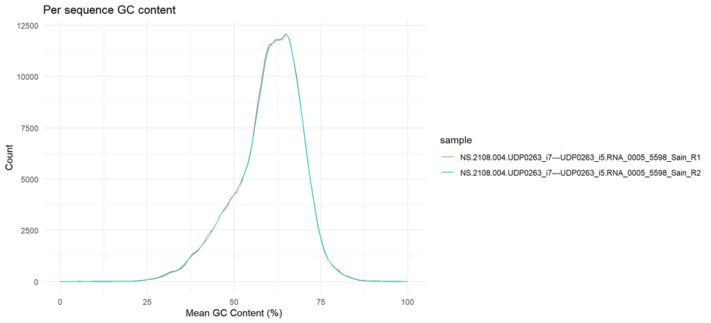

```r
# Plot per sequence GC content
qc_read_collection = fastqc_statistics[[3]]
qc_plot_collection(qc_read_collection, "Per sequence GC content")
```

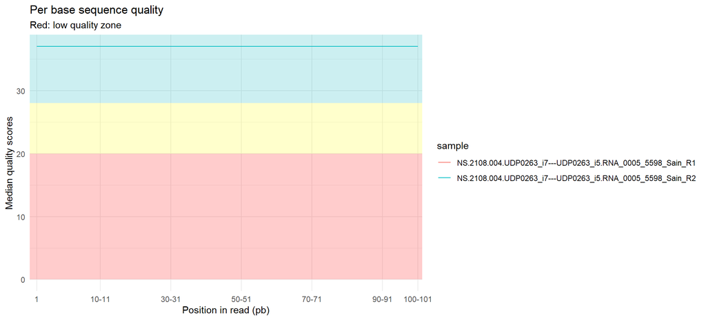

```r
# Per base sequence quality
qc_plot_collection(qc_read_collection, "Per base sequence quality")
```

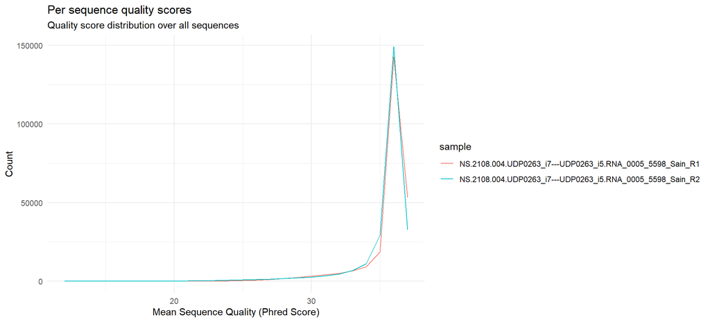

```r
# Per sequence quality scores
qc_plot_collection(qc_read_collection, "Per sequence quality scores")
```

```r
# Overrepresented sequences
qc_plot_collection(qc_read_collection, "Overrepresented sequences")
```

[output not shown]

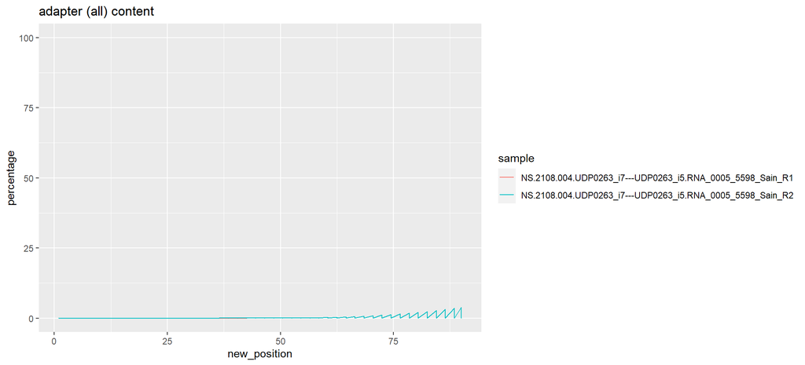

```r
# Adapter content
if(is.numeric(qc_read_collection$adapter_content$Position)==F) {
newmean_position = c(1:length(qc_read_collection$adapter_content$Position))[regexpr('-',qc_read_collection$adapter_content$Position,fixed = T)>0]
means = strsplit(qc_read_collection$adapter_content$Position[newmean_position],'-')
means = sapply(means,function(x) mean(as.numeric(x)))
qc_read_collection$adapter_content$new_position = ''
qc_read_collection$adapter_content$new_position[newmean_position] = means
qc_read_collection$adapter_content$new_position[-newmean_position] = qc_read_collection$adapter_content$Position[-newmean_position]
qc_read_collection$adapter_content$new_position = as.numeric(qc_read_collection$adapter_content$new_position)
}
if(is.numeric(qc_read_collection$adapter_content$Position)==T) {
  qc_read_collection$adapter_content$new_position = qc_read_collection$adapter_content$Position
}

adapter_data = qc_read_collection$adapter_content[,-2] %>% pivot_longer(cols = !c(sample,new_position))

adapter_data %>%
  ggplot( aes(x=new_position, y=value, group=sample, color=sample)) +
    geom_line() +
    ylim(0, 100) + ylab('percentage') + ggtitle('adapter (all) content')
```

Time for this code chunk to run: 0.953 secs